# MSc Data Science: R for Big Data

Pr. Charles Bouveyron (Email: charles.bouveyron@univ-cotedazur.fr / Twitter: @cbouveyron)

Last updated on 2018-10-24

# 1 Preamble

## 1.1 Who I am?

A professor/researcher using R for more than 10 years and who developed more than 10 R packages.

## 1.2 Organization of the course

The course will be organized as follows:

- lectures,
- pratical sessions,
- applied projects.

# 2 Introduction

## 2.1 The softwares for Data Science

R is one of the most used softwares for Data Science:

- https://cran.r-project.org
- http://www.rstudio.com

But there are of course good alternatives:

- Python (the SciKitLearn initiative is very good and clearly is missing in R!)
- not free softwares: SAS, Matlab, …

## 2.2 Why R for Data Science?

R is very good for DS because of:

- connected to the researchers / newest technologies
- easy to pulish new codes
- a community behind the software

## 2.3 Working with R - Lesson 101

To start a project in R:

- you’ll need a Rstudio session
- a blank script > open a new R script to do some serious project
- use only the console for simple calulations
- the plot panel allows to see graphical results

Two main commands:

- `run` is devoted to execute line by line the code
- `source` will execute the whole script at once

# 3 R basics

> Note: the Base R Cheat Sheet can be downloaded on the Rstudio website: https://www.rstudio.com/resources/cheatsheets/

## 3.1 R as simple calculus tool

R can be used to make simple (and less simple) caclulations:

```r
2+2
```

```
## [1] 4
```

```r
exp(-2)
```

```
## [1] 0.1353353
```

All calculations are made using vectors (or matrices later) and the `[1]` is a trace of this vector nature

```r
rnorm(15)
```

```
##  [1]  2.17003602  1.48711220 -1.61901512  0.21876014  0.16955620
##  [6] -1.62737701 -0.52439921 -1.14246050  0.54693650  0.07322032
## [11] -0.51844433  0.81450223  0.37016113  0.51219555  0.16388506
```

This command produces a vector of 15 values and the number within brackets at the beginning of the lines indicate the rank of the values in the vector.

```r
x = 2
```

It is possible to store the results in variables. The `=` operator assigns the value to the variable. When all is ok, R does not display anything!

It is also possible to use the arrow operator `->` which usually works in the same way as the `=` operator

```r
a = c(1,2,3,4,5)
```

The `c()` function allows to create vectors. Warning: all vectors must be of the same type (numeric, characters, booleans)!

This is a vector of booleans:

```r
a = c(TRUE,FALSE,TRUE,FALSE,FALSE)
```

All operators are working on vectors elements by elements:

```r
a = c(1,2,3,4,5)
b = c(2,1,4,6,1)
a / b
```

```
## [1] 0.5000000 2.0000000 0.7500000 0.6666667 5.0000000
```

The resulting vector is of the same size of the two input vectors.

> Note: the operator for matrix multiplication is %*%

```r
c = a / b
c^2
```

```
## [1]  0.2500000  4.0000000  0.5625000  0.4444444 25.0000000
```

Here, the expentation is again element by element.

It is usually very easy to translate Maths into code:

```r
xbar = sum(a) / length(a)
xbar
```

```
## [1] 3
```

## 3.2 How to find a function in the documentation

The R documentation is very well structured and it is easy to find information from it. A search in the documentation is usually in two steps:

1. Search with a key word within the documentation:

```r
??student
```

2. Access the documentation of the wanted function:

```r
?t.test
```

The documentation is always organised in the same manner:

- `Description`: a short description in English of the method implemented in the function
- `Usage`: the way the function should be used, with all input parameters and their default values
- `Arguments`: a detailed explenation of the input parameters
- `Values`: a detailed explenation of the output fields

There are plenty of already coded functions:

```r
mean(a)
```

```
## [1] 3
```

```r
sd(a)
```

```
## [1] 1.581139
```

```r
range(a)
```

```
## [1] 1 5
```

```r
max(a)
```

```
## [1] 5
```

> Note: missing values are represented in R with the `NA` type. It is possible to locate missing values using the `is.na()` function.

## 3.3 Basics of ploting

In R, the generic plot function allows to output a graphic from some object:

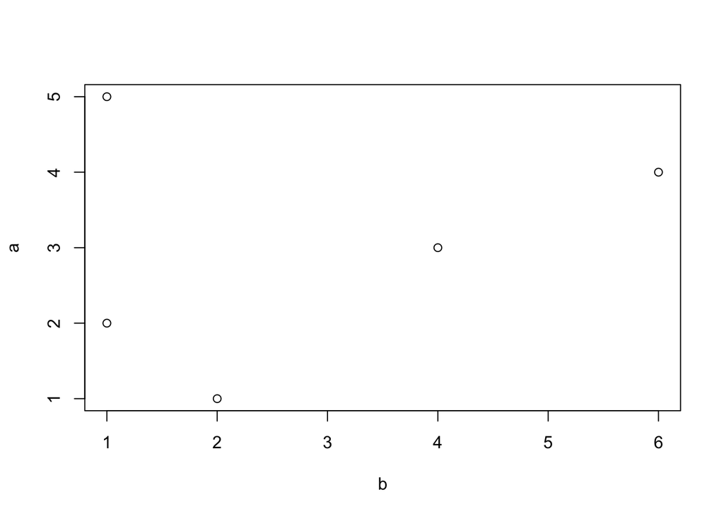

```r
a = c(1,2,3,4,5)
b = c(2,1,4,6,1)
plot(b,a)
```

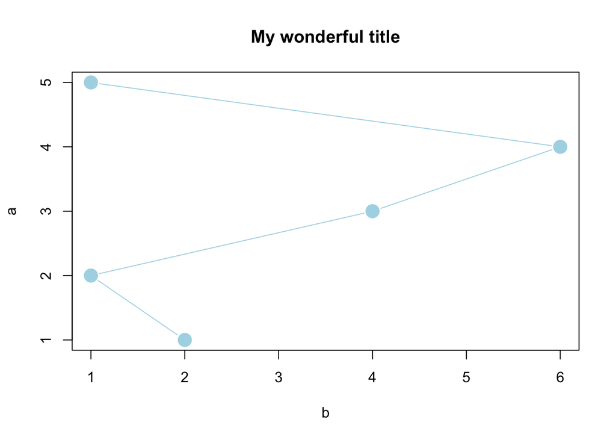

```r
plot(b,a,pch=19,col='lightblue',cex=2,type='b')
title(main='My wonderful title')
```

> Note: a plot is build like a Lego, meaning it is not possible to mify something whitout restarting from zero!

## 3.4 Loading and saving data

Two options:

1. Data in CSV file, or similar (mydata.csv)
2. Data in Rdata format (mydata.Rdata)

How to proceed for CSV:

```r
# Load the data into X
X = read.csv('path/toward/thefile.csv')

# Save some data into a file
write.csv(X,file='path/toward/thefile2.csv')
```

How to proceed for Rdata:

```r
# Load the data
load('path/toward/thefile.Rdata')

# Save some data into a file
save(X,Y,a,b,out,file='path/toward/thefile2.Rdata')
```

> Note: the `rm(list=ls())` allows to clean the working space.

## 3.5 Exercice

Write a script allowing to load a vector file and “remove” the missing values.

```r
# Load data
x = read.csv("path/to/myfile.csv")
x = as.vector(x$x) # to ensure that x is a vector

# Count the number of NAs
prop = sum(is.na(x)) / lenght(x)

# If too many NAs, remove them
if (prop > 0.05){
  x = x[-which(is.na(x))]
}

# Otherwise, replace NAs with the mean
if (prop <= 0.05){
  m = mean(x,na.rm = TRUE)
  x[which(is.na(x))] = m
}
```

# 4 Advanced R

## 4.1 Objects and expressions

First, it important to understand that R has two kinds of “objects”:

- expresssions: operators and functions,
- objects: vectors, matrices, lists, dataframes, …

To differentiate between functions and objects, functions have to be called every time with brackets `()`!

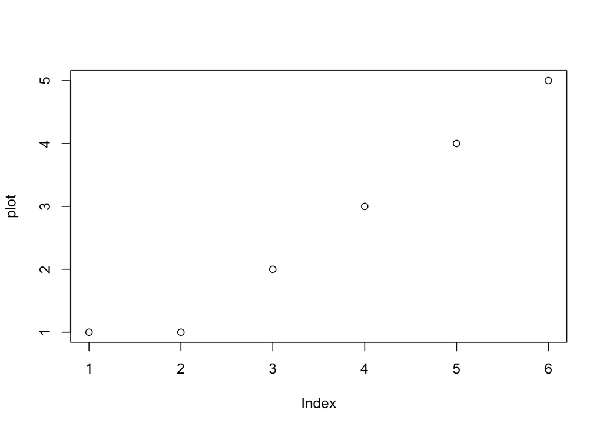

```r
plot = c(1,1,2,3,4,5)
plot(plot)
```

About the functions, the arguments (imput parameters) can be provided in any order:

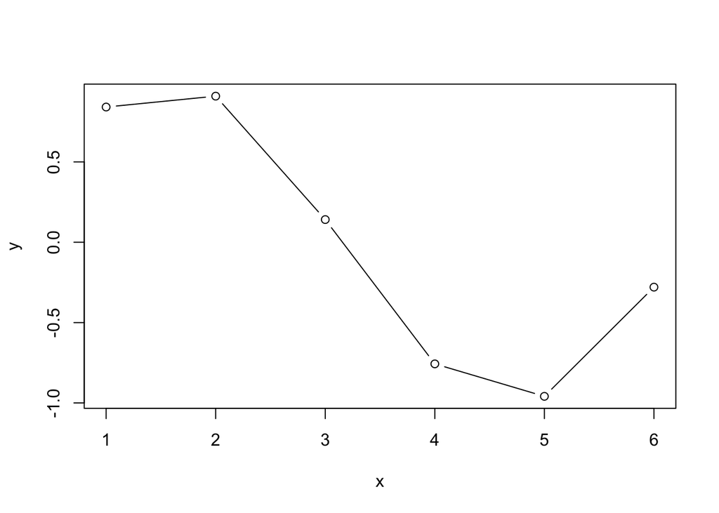

```r
x = c(1,2,3,4,5,6)
y = sin(x)
plot(x,y,type='b')
```

or

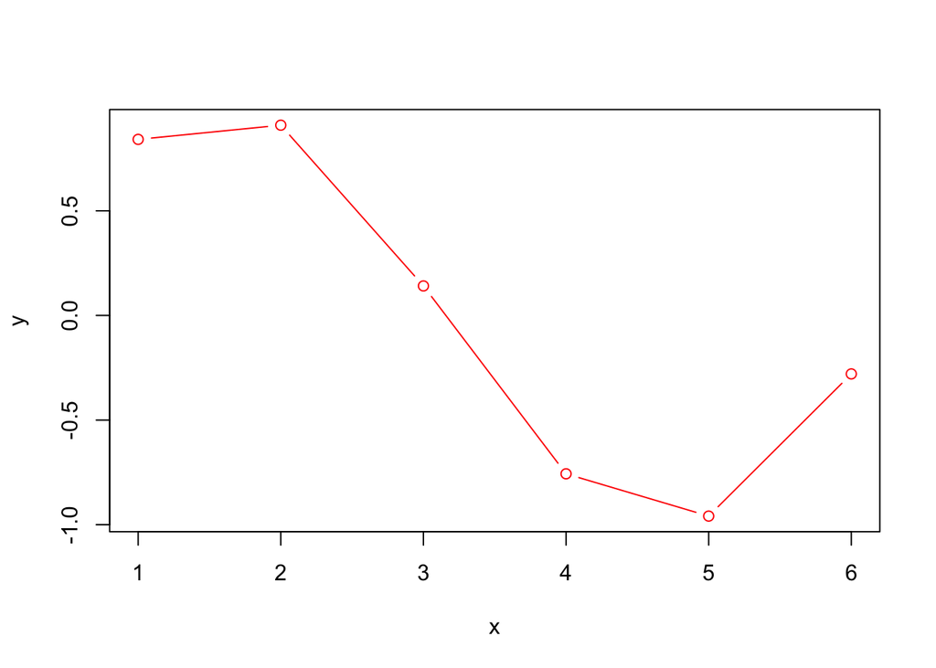

```r
plot(y=y,x=x,col='red',type='b')
```

if you declare clearly which argument you are providing!

## 4.2 Vectors

Vectors can be created with the `c()` function:

```r
x = c(1,2,3,4,5)
x = c(TRUE,FALSE,TRUE)
x = c('tyty',"tutu",'yuyu')
```

or some other ways:

```r
x = seq(1,10)
x
```

```
##  [1]  1  2  3  4  5  6  7  8  9 10
```

```r
x = seq(1,11,by = 1.5)
x
```

```
## [1]  1.0  2.5  4.0  5.5  7.0  8.5 10.0
```

```r
x = seq(1,10,length.out = 100)
x
```

```
##   [1]  1.000000  1.090909  1.181818  1.272727  1.363636  1.454545  1.545455
##   [8]  1.636364  1.727273  1.818182  1.909091  2.000000  2.090909  2.181818
##  [15]  2.272727  2.363636  2.454545  2.545455  2.636364  2.727273  2.818182
##  [22]  2.909091  3.000000  3.090909  3.181818  3.272727  3.363636  3.454545
##  [29]  3.545455  3.636364  3.727273  3.818182  3.909091  4.000000  4.090909
##  [36]  4.181818  4.272727  4.363636  4.454545  4.545455  4.636364  4.727273
##  [43]  4.818182  4.909091  5.000000  5.090909  5.181818  5.272727  5.363636
##  [50]  5.454545  5.545455  5.636364  5.727273  5.818182  5.909091  6.000000
##  [57]  6.090909  6.181818  6.272727  6.363636  6.454545  6.545455  6.636364
##  [64]  6.727273  6.818182  6.909091  7.000000  7.090909  7.181818  7.272727
##  [71]  7.363636  7.454545  7.545455  7.636364  7.727273  7.818182  7.909091
##  [78]  8.000000  8.090909  8.181818  8.272727  8.363636  8.454545  8.545455
##  [85]  8.636364  8.727273  8.818182  8.909091  9.000000  9.090909  9.181818
##  [92]  9.272727  9.363636  9.454545  9.545455  9.636364  9.727273  9.818182
##  [99]  9.909091 10.000000
```

This would be very useful to get a nice plot of the `sinus` function.

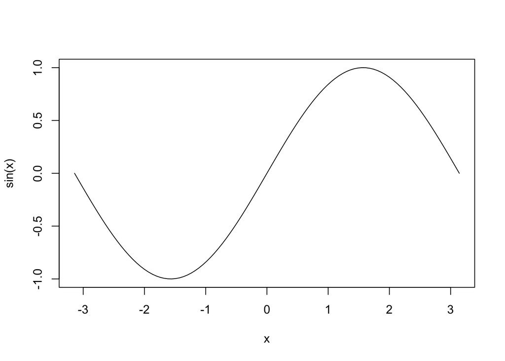

```r
x = seq(-pi,pi,length.out = 100)
plot(x,sin(x),type='l')
```

You can also use the `:` operator which equivalent to the default `seq()` function.

```r
x = seq(1:10)
x
```

```
##  [1]  1  2  3  4  5  6  7  8  9 10
```

```r
y = 1:10
y
```

```
##  [1]  1  2  3  4  5  6  7  8  9 10
```

```r
w = 0.5:10
w
```

```
##  [1] 0.5 1.5 2.5 3.5 4.5 5.5 6.5 7.5 8.5 9.5
```

And the last way of creating vectors is to use the `rep` function.

```r
x = rep(0,10)
x
```

```
##  [1] 0 0 0 0 0 0 0 0 0 0
```

This is useful in particular to initialize a vector which will be used in a loop or a function.

> Tip: always initialize your vectors with a “strange” value for the task (for instance NA’s)

```r
m = rep(NA,10)
for (i in 1:10) m[i] = mean(rnorm(10))
m
```

```
##  [1] -0.11405061  0.39702785  0.11392546  0.61838232  0.28013730
##  [6] -0.09440300  0.04028702 -0.01811990  0.35456603 -0.33900429
```

## 4.3 Matrices

**Matrices** can be created with the `matrix` function:

```r
A = matrix(c(1,2,3,4,5,6),nrow = 2,byrow = TRUE)
A
```

```
##      [,1] [,2] [,3]
## [1,]    1    2    3
## [2,]    4    5    6
```

Another option would be to use the `cbind` and `rdind` functions:

```r
A = cbind(c(1,2),c(2,3),c(4,5))
A
```

```
##      [,1] [,2] [,3]
## [1,]    1    2    4
## [2,]    2    3    5
```

```r
A = rbind(c(1,2,3),c(4,5,6))
A
```

```
##      [,1] [,2] [,3]
## [1,]    1    2    3
## [2,]    4    5    6
```

To access vectors and matrices, we cannot use the barckets ()! Instead, we use the square brackets `[...]`

```r
x = seq(1,10,length.out = 25)
# Access the 5th element of x
x[5]
```

```
## [1] 2.5
```

```r
# Access all elements between the 5th and the 15th elements
x[5:15]
```

```
##  [1] 2.500 2.875 3.250 3.625 4.000 4.375 4.750 5.125 5.500 5.875 6.250
```

```r
# Access all elements except those between 5 and 15
y = x[-(5:15)]
y
```

```
##  [1]  1.000  1.375  1.750  2.125  6.625  7.000  7.375  7.750  8.125  8.500
## [11]  8.875  9.250  9.625 10.000
```

```r
length(y)
```

```
## [1] 14
```

With the square brackets, you can also modify the values of a vector:

```r
x[5] = NA
x
```

```
##  [1]  1.000  1.375  1.750  2.125     NA  2.875  3.250  3.625  4.000  4.375
## [11]  4.750  5.125  5.500  5.875  6.250  6.625  7.000  7.375  7.750  8.125
## [21]  8.500  8.875  9.250  9.625 10.000
```

It is also possible to do some conditional access:

```r
x[is.na(x)] = -1
x
```

```
##  [1]  1.000  1.375  1.750  2.125 -1.000  2.875  3.250  3.625  4.000  4.375
## [11]  4.750  5.125  5.500  5.875  6.250  6.625  7.000  7.375  7.750  8.125
## [21]  8.500  8.875  9.250  9.625 10.000
```

```r
x[x < 4] = 0
x
```

```
##  [1]  0.000  0.000  0.000  0.000  0.000  0.000  0.000  0.000  4.000  4.375
## [11]  4.750  5.125  5.500  5.875  6.250  6.625  7.000  7.375  7.750  8.125
## [21]  8.500  8.875  9.250  9.625 10.000
```

```r
x[x < 4 | x > 8] = NA
x
```

```
##  [1]    NA    NA    NA    NA    NA    NA    NA    NA 4.000 4.375 4.750
## [12] 5.125 5.500 5.875 6.250 6.625 7.000 7.375 7.750    NA    NA    NA
## [23]    NA    NA    NA
```

> Note: the `|` operator denotes a OR. The AND is denoted by the `&` operator.

For matrices, you will have to provide position information about rows and columns:

```r
A = diag(1,5)
A
```

```
##      [,1] [,2] [,3] [,4] [,5]
## [1,]    1    0    0    0    0
## [2,]    0    1    0    0    0
## [3,]    0    0    1    0    0
## [4,]    0    0    0    1    0
## [5,]    0    0    0    0    1
```

```r
A[1:2,4:5]
```

```
##      [,1] [,2]
## [1,]    0    0
## [2,]    0    0
```

If you would like to access all rows (resp. columns) of a matrix, you can use the “nothing” operator:

```r
A[,4:5]
```

```
##      [,1] [,2]
## [1,]    0    0
## [2,]    0    0
## [3,]    0    0
## [4,]    1    0
## [5,]    0    1
```

In some cases, you perhaps would like to access some specific locations:

```r
A[c(1,3),c(2,5)]
```

```
##      [,1] [,2]
## [1,]    0    0
## [2,]    0    0
```

## 4.4 Lists

**Lists** are objects able to store information of different types. All functions return lists, so it is important to be able to manipulate them!

```r
mylist = list(name='Charles',age=28,married=TRUE)
mylist
```

```
## $name
## [1] "Charles"
##
## $age
## [1] 28
##
## $married
## [1] TRUE
```

```r
mylist$name = 'Tutu'
mylist
```

```
## $name
## [1] "Tutu"
##
## $age
## [1] 28
##
## $married
## [1] TRUE
```

```r
mylist$Nb_of_cats = 4
mylist
```

```
## $name
## [1] "Tutu"
##
## $age
## [1] 28
##
## $married
## [1] TRUE
##
## $Nb_of_cats
## [1] 4
```

```r
out = t.test(1:10, y = c(7:20))
out
```

```
##
##  Welch Two Sample t-test
##
## data:  1:10 and c(7:20)
## t = -5.4349, df = 21.982, p-value = 1.855e-05
## alternative hypothesis: true difference in means is not equal to 0
## 95 percent confidence interval:
##  -11.052802  -4.947198
## sample estimates:
## mean of x mean of y
##       5.5      13.5
```

```r
print.default(out)
```

```
## $statistic
##        t
## -5.43493
##
## $parameter
##       df
## 21.98221
##
## $p.value
## [1] 1.855282e-05
##
## $conf.int
## [1] -11.052802  -4.947198
## attr(,"conf.level")
## [1] 0.95
##
## $estimate
## mean of x mean of y
##       5.5      13.5
##
## $null.value
## difference in means
##                   0
##
## $alternative
## [1] "two.sided"
##
## $method
## [1] "Welch Two Sample t-test"
##
## $data.name
## [1] "1:10 and c(7:20)"
##
## attr(,"class")
## [1] "htest"
```

```r
out$statistic
```

```
##        t
## -5.43493
```

```r
sqrt(abs(out$statistic))
```

```
##        t
## 2.331294
```

```r
out$p.value
```

```
## [1] 1.855282e-05
```

## 4.5 Data frames

The last object is the `data.frame` and it is devoted to store data sets. In a `data.frame`, rows are for individuals and columns are for variables.

```r
# We create a data.frame with 28 individuals and 3 variables (2 numeric and 1 categorical)
X = data.frame(x = seq(1,10,length.out = 28),
               y = seq(-3,3,length.out = 28),
               sex = c(rep('M',10),rep('F',18)))
X
```

```
##            x          y sex
## 1   1.000000 -3.0000000   M
## 2   1.333333 -2.7777778   M
## 3   1.666667 -2.5555556   M
## 4   2.000000 -2.3333333   M
## 5   2.333333 -2.1111111   M
## 6   2.666667 -1.8888889   M
## 7   3.000000 -1.6666667   M
## 8   3.333333 -1.4444444   M
## 9   3.666667 -1.2222222   M
## 10  4.000000 -1.0000000   M
## 11  4.333333 -0.7777778   F
## 12  4.666667 -0.5555556   F
## 13  5.000000 -0.3333333   F
## 14  5.333333 -0.1111111   F
## 15  5.666667  0.1111111   F
## 16  6.000000  0.3333333   F
## 17  6.333333  0.5555556   F
## 18  6.666667  0.7777778   F
## 19  7.000000  1.0000000   F
## 20  7.333333  1.2222222   F
## 21  7.666667  1.4444444   F
## 22  8.000000  1.6666667   F
## 23  8.333333  1.8888889   F
## 24  8.666667  2.1111111   F
## 25  9.000000  2.3333333   F
## 26  9.333333  2.5555556   F
## 27  9.666667  2.7777778   F
## 28 10.000000  3.0000000   F
```

Data.frame can be used as matrices or lists:

```r
X[5:10,]
```

```
##           x         y sex
## 5  2.333333 -2.111111   M
## 6  2.666667 -1.888889   M
## 7  3.000000 -1.666667   M
## 8  3.333333 -1.444444   M
## 9  3.666667 -1.222222   M
## 10 4.000000 -1.000000   M
```

```r
X$sex
```

```
##  [1] M M M M M M M M M M F F F F F F F F F F F F F F F F F F
## Levels: F M
```

```r
X[,3]
```

```
##  [1] M M M M M M M M M M F F F F F F F F F F F F F F F F F F
## Levels: F M
```

```r
summary(X)
```

```
##        x               y        sex
##  Min.   : 1.00   Min.   :-3.0   F:18
##  1st Qu.: 3.25   1st Qu.:-1.5   M:10
##  Median : 5.50   Median : 0.0
##  Mean   : 5.50   Mean   : 0.0
##  3rd Qu.: 7.75   3rd Qu.: 1.5
##  Max.   :10.00   Max.   : 3.0
```

Some useful functions to get information about objects:

```r
#Length of a vector
length(x)
```

```
## [1] 25
```

```r
# Length of a list (nb of fields)
length(mylist)
```

```
## [1] 4
```

```r
# For matrices and data.frames
nrow(X)
```

```
## [1] 28
```

```r
ncol(X)
```

```
## [1] 3
```

```r
# For data.frames
colnames(X)
```

```
## [1] "x"   "y"   "sex"
```

```r
rownames(X)
```

```
##  [1] "1"  "2"  "3"  "4"  "5"  "6"  "7"  "8"  "9"  "10" "11" "12" "13" "14"
## [15] "15" "16" "17" "18" "19" "20" "21" "22" "23" "24" "25" "26" "27" "28"
```

It is also possible to modify the names of variables and individuals

```r
colnames(X) = c('Var 1','Var 2','Var 3')
X
```

```
##        Var 1      Var 2 Var 3
## 1   1.000000 -3.0000000     M
## 2   1.333333 -2.7777778     M
## 3   1.666667 -2.5555556     M
## 4   2.000000 -2.3333333     M
## 5   2.333333 -2.1111111     M
## 6   2.666667 -1.8888889     M
## 7   3.000000 -1.6666667     M
## 8   3.333333 -1.4444444     M
## 9   3.666667 -1.2222222     M
## 10  4.000000 -1.0000000     M
## 11  4.333333 -0.7777778     F
## 12  4.666667 -0.5555556     F
## 13  5.000000 -0.3333333     F
## 14  5.333333 -0.1111111     F
## 15  5.666667  0.1111111     F
## 16  6.000000  0.3333333     F
## 17  6.333333  0.5555556     F
## 18  6.666667  0.7777778     F
## 19  7.000000  1.0000000     F
## 20  7.333333  1.2222222     F
## 21  7.666667  1.4444444     F
## 22  8.000000  1.6666667     F
## 23  8.333333  1.8888889     F
## 24  8.666667  2.1111111     F
## 25  9.000000  2.3333333     F
## 26  9.333333  2.5555556     F
## 27  9.666667  2.7777778     F
## 28 10.000000  3.0000000     F
```

```r
rownames(X) = paste('Individual',1:28)
X
```

```
##                   Var 1      Var 2 Var 3
## Individual 1   1.000000 -3.0000000     M
## Individual 2   1.333333 -2.7777778     M
## Individual 3   1.666667 -2.5555556     M
## Individual 4   2.000000 -2.3333333     M
## Individual 5   2.333333 -2.1111111     M
## Individual 6   2.666667 -1.8888889     M
## Individual 7   3.000000 -1.6666667     M
## Individual 8   3.333333 -1.4444444     M
## Individual 9   3.666667 -1.2222222     M
## Individual 10  4.000000 -1.0000000     M
## Individual 11  4.333333 -0.7777778     F
## Individual 12  4.666667 -0.5555556     F
## Individual 13  5.000000 -0.3333333     F
## Individual 14  5.333333 -0.1111111     F
## Individual 15  5.666667  0.1111111     F
## Individual 16  6.000000  0.3333333     F
## Individual 17  6.333333  0.5555556     F
## Individual 18  6.666667  0.7777778     F
## Individual 19  7.000000  1.0000000     F
## Individual 20  7.333333  1.2222222     F
## Individual 21  7.666667  1.4444444     F
## Individual 22  8.000000  1.6666667     F
## Individual 23  8.333333  1.8888889     F
## Individual 24  8.666667  2.1111111     F
## Individual 25  9.000000  2.3333333     F
## Individual 26  9.333333  2.5555556     F
## Individual 27  9.666667  2.7777778     F
## Individual 28 10.000000  3.0000000     F
```

```r
X["Individual 26",]
```

```
##                  Var 1    Var 2 Var 3
## Individual 26 9.333333 2.555556     F
```

## 4.6 Some exercises

> Exercise: Create two vectors of different dimensions and insert the second one in the first one between the 2nd and 3rd elements.

```r
a = c(1,2,3,4,5)
b = runif(10)
c = c(a[1:2],b,a[-(1:2)])
c
```

```
##  [1] 1.00000000 2.00000000 0.43379645 0.09104675 0.73130889 0.30604440
##  [7] 0.99378992 0.13625604 0.28864278 0.65000920 0.40948890 0.42390750
## [13] 3.00000000 4.00000000 5.00000000
```

> Exercise: Draw 100 numbers from a Uniform distribution on [0,1] and count how many values are larger than 0.5

```r
x = runif(100,min = 0,max = 1)
sum(x>=0.5)
```

```
## [1] 46
```

```r
length(x[x>=0.5])
```

```
## [1] 46
```

> Exercise: Draw 100 couples $(x,y)$ randomly in the square $[0,1]^2$ (use a data.frame to store the data). Count how many couples are within the square $[0.5,1]^2$. Plot the couples and display with a red point the mean of all points.

```r
X = data.frame(x = runif(100), y = runif(100))
sum(X$x >= 0.5 & X$y >= 0.5)
```

```
## [1] 25
```

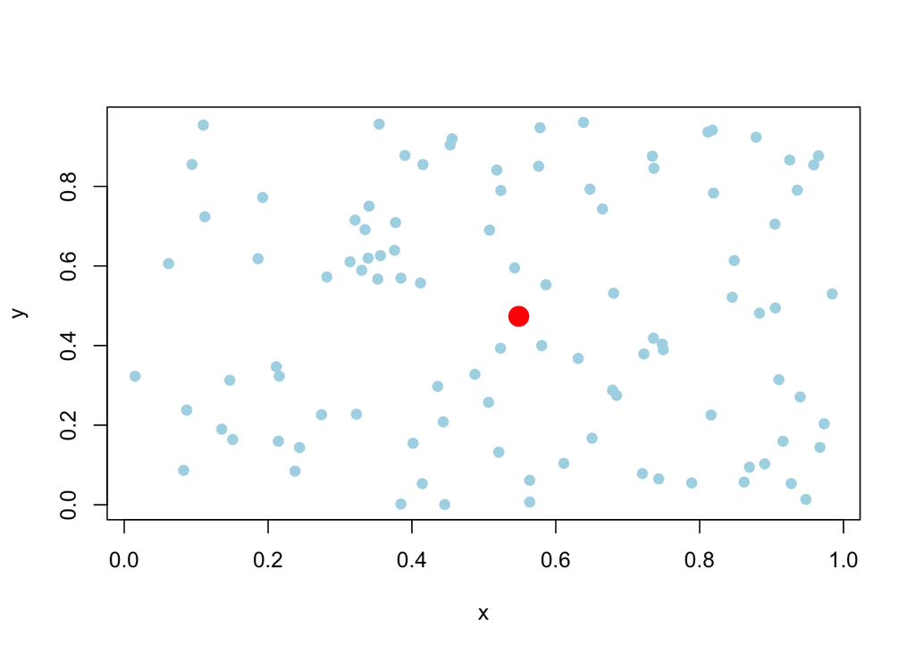

```r
plot(X,col='lightblue',pch=19)
mean = colMeans(X)
points(mean[1],mean[2],col='red',pch=19,cex=2)
```

> Exercise: It is Spring! We consider a field of flower bulbes. We have 100 bulbes in a field of 1m x 1m. We know that the probability that a bulbe blooms is 0.85 (use a data.frame to store the data). Simulate the blossoming of the bulbes!

```r
X = data.frame(x = runif(100), y = runif(100),
               b = rbinom(100,size = 1,prob = 0.85))
X
```

```
##              x          y b
## 1   0.36041257 0.01905814 1
## 2   0.42931858 0.54543454 1
## 3   0.43104071 0.40916856 1
## 4   0.36454553 0.30032970 0
## 5   0.24949117 0.18509208 1
## 6   0.35187746 0.95527754 1
## 7   0.30521440 0.85363699 0
## 8   0.44648990 0.91214969 1
## 9   0.72402361 0.62799066 1
## 10  0.16764428 0.87307451 1
## 11  0.23760750 0.82733064 1
## 12  0.52973773 0.60770633 0
## 13  0.43251910 0.49419244 0
## 14  0.25015874 0.04713288 0
```

[output cut: 86 more lines]

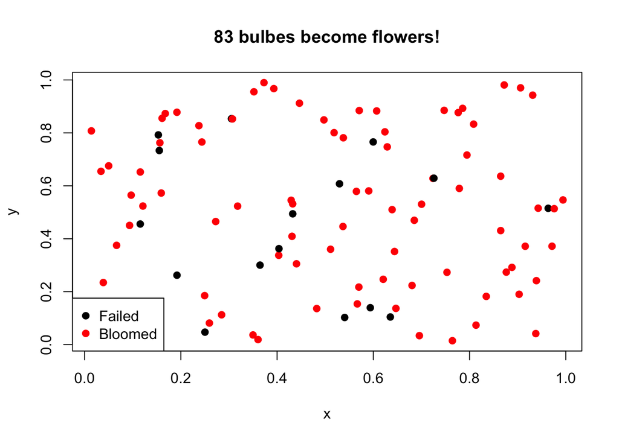

```r
plot(X[,1:2],pch=19,col=X$b+1)
nb = sum(X$b == 1)
title(main = paste(nb,"bulbes become flowers!"))
legend("bottomleft",legend = c('Failed','Bloomed'),col=c(1,2),pch=19)
```

# 5 The graphical system

## 5.1 Basic plots and legends

The graphical system is very complex and works in Lego fashion, i.e. it is not possible to remove something on plot wihout clearing everything!

Of course, it is possible to add on a figure texts, legend, title, etc … and to save the figure in an image format (png, jpg, pdf, eps, …)

The window of the plot is automatically set up according to the data scale.

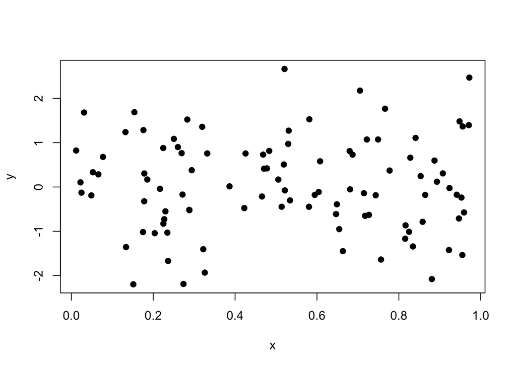

```r
x = runif(100)
y = rnorm(100)
plot(x,y,pch=19)
```

It is possible to resize the window by using the `xlim` and `ylim` arguments.

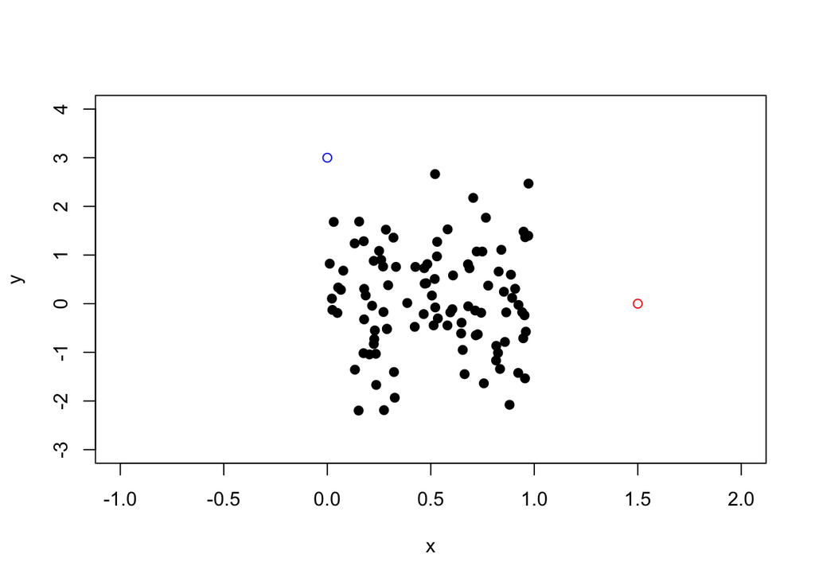

```r
plot(x,y,pch=19,xlim=c(-1,2),ylim=c(-3,4))
points(1.5,0,col='red')
points(0,3,col='blue')
```

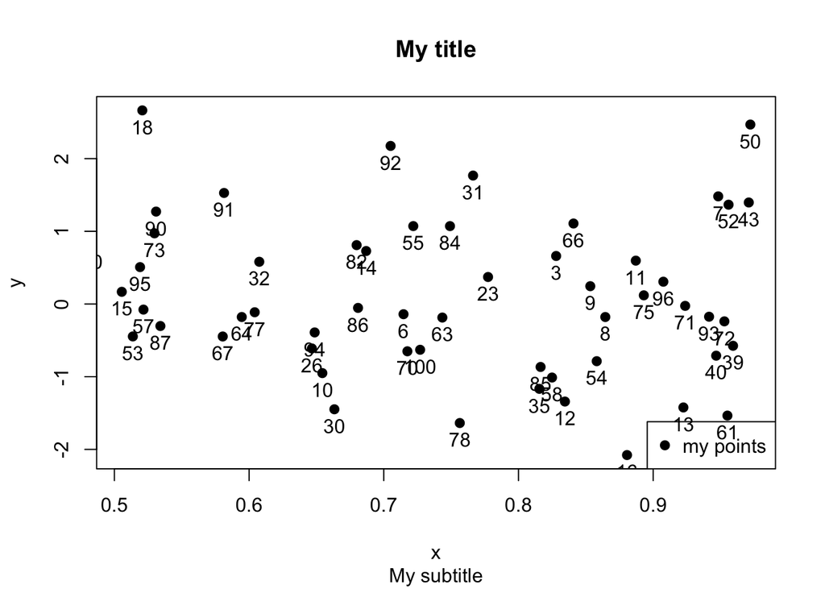

```r
plot(x[x >= 0.5],y[x >= 0.5],pch=19,
     xlab='x',ylab='y',main='My title')
title(sub='My subtitle')
legend("bottomright",legend = 'my points',col=1,pch=19)
text(x,y,1:length(x >= 0.5),pos = 1)
```

To draw some line (for instance for linear regression), we use the `abline` function:

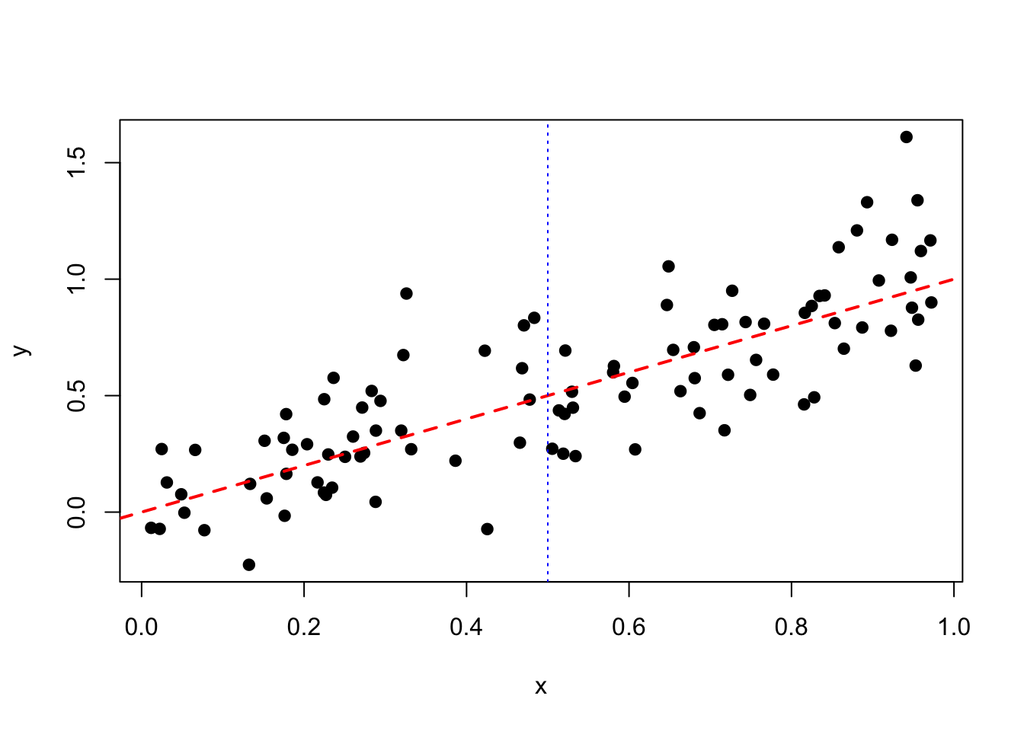

```r
plot(x,x+rnorm(100,0,0.2),pch=19,ylab='y')
abline(a=0,b=1,lty=2,lwd=2,col='red')
abline(v = 0.5,lty=3,col='blue')
```

It is also possible to add texts in the margin:

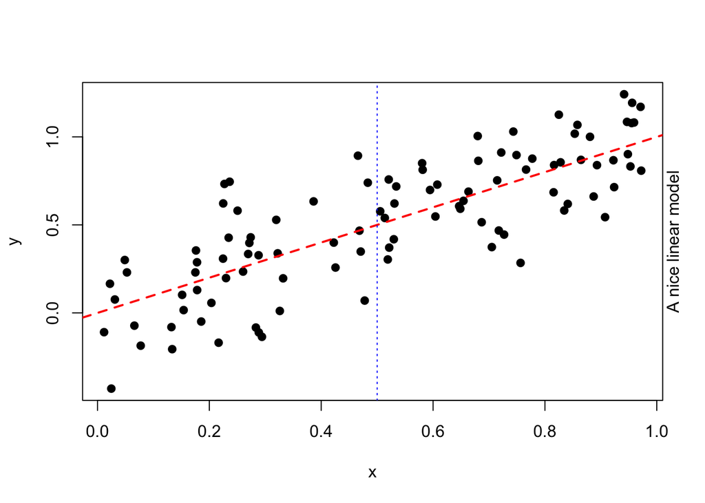

```r
plot(x,x+rnorm(100,0,0.2),pch=19,ylab='y')
abline(a=0,b=1,lty=2,lwd=2,col='red')
abline(v = 0.5,lty=3,col='blue')
mtext("A nice linear model",side = 4)
```

## 5.2 The ggplot package

# 6 Programming with R

# 7 Reporting with R